# Risk Factor Analysis

## Outcome Variable

**Outcome Variable:** ever_swasted

## Predictor Variables

**Intervention Variable:** vagbrth

**Adjustment Set:**

unadjusted

## Stratifying Variables

The analysis was stratified on these variable(s):

- agecat
- studyid
- country

## Data Summary

| agecat | studyid | country | vagbrth | ever_swasted | n_cell | n |
| --- | --- | --- | --- | --- | --- | --- |
| 0-24 months (no birth wast) | CMC-V-BCS-2002 | INDIA | 0 | 0 | 20 | 368 |
| 0-24 months (no birth wast) | CMC-V-BCS-2002 | INDIA | 0 | 1 | 5 | 368 |
| 0-24 months (no birth wast) | CMC-V-BCS-2002 | INDIA | 1 | 0 | 293 | 368 |
| 0-24 months (no birth wast) | CMC-V-BCS-2002 | INDIA | 1 | 1 | 50 | 368 |
| 0-24 months (no birth wast) | IRC | INDIA | 0 | 0 | 55 | 409 |
| 0-24 months (no birth wast) | IRC | INDIA | 0 | 1 | 15 | 409 |
| 0-24 months (no birth wast) | IRC | INDIA | 1 | 0 | 277 | 409 |
| 0-24 months (no birth wast) | IRC | INDIA | 1 | 1 | 62 | 409 |
| 0-24 months (no birth wast) | NIH-Crypto | BANGLADESH | 0 | 0 | 198 | 496 |
| 0-24 months (no birth wast) | NIH-Crypto | BANGLADESH | 0 | 1 | 4 | 496 |
| 0-24 months (no birth wast) | NIH-Crypto | BANGLADESH | 1 | 0 | 284 | 496 |
| 0-24 months (no birth wast) | NIH-Crypto | BANGLADESH | 1 | 1 | 10 | 496 |
| 0-24 months (no birth wast) | PROBIT | BELARUS | 0 | 0 | 1926 | 16879 |
| 0-24 months (no birth wast) | PROBIT | BELARUS | 0 | 1 | 26 | 16879 |
| 0-24 months (no birth wast) | PROBIT | BELARUS | 1 | 0 | 14749 | 16879 |
| 0-24 months (no birth wast) | PROBIT | BELARUS | 1 | 1 | 178 | 16879 |
| 0-24 months (no birth wast) | PROVIDE | BANGLADESH | 0 | 0 | 158 | 687 |
| 0-24 months (no birth wast) | PROVIDE | BANGLADESH | 0 | 1 | 1 | 687 |
| 0-24 months (no birth wast) | PROVIDE | BANGLADESH | 1 | 0 | 510 | 687 |
| 0-24 months (no birth wast) | PROVIDE | BANGLADESH | 1 | 1 | 18 | 687 |
| 0-24 months (no birth wast) | TanzaniaChild2 | TANZANIA, UNITED REPUBLIC OF | 0 | 0 | 195 | 2355 |
| 0-24 months (no birth wast) | TanzaniaChild2 | TANZANIA, UNITED REPUBLIC OF | 0 | 1 | 17 | 2355 |
| 0-24 months (no birth wast) | TanzaniaChild2 | TANZANIA, UNITED REPUBLIC OF | 1 | 0 | 2039 | 2355 |
| 0-24 months (no birth wast) | TanzaniaChild2 | TANZANIA, UNITED REPUBLIC OF | 1 | 1 | 104 | 2355 |
| 0-24 months (no birth wast) | ZVITAMBO | ZIMBABWE | 0 | 0 | 1110 | 13522 |
| 0-24 months (no birth wast) | ZVITAMBO | ZIMBABWE | 0 | 1 | 32 | 13522 |
| 0-24 months (no birth wast) | ZVITAMBO | ZIMBABWE | 1 | 0 | 11940 | 13522 |
| 0-24 months (no birth wast) | ZVITAMBO | ZIMBABWE | 1 | 1 | 440 | 13522 |
| 0-6 months (no birth wast) | CMC-V-BCS-2002 | INDIA | 0 | 0 | 20 | 350 |
| 0-6 months (no birth wast) | CMC-V-BCS-2002 | INDIA | 0 | 1 | 3 | 350 |

[output cut: 54 more lines]

The following strata were considered:

- agecat: 0-24 months (no birth wast), studyid: CMC-V-BCS-2002, country: INDIA
- agecat: 0-24 months (no birth wast), studyid: IRC, country: INDIA
- agecat: 0-24 months (no birth wast), studyid: NIH-Crypto, country: BANGLADESH
- agecat: 0-24 months (no birth wast), studyid: PROBIT, country: BELARUS
- agecat: 0-24 months (no birth wast), studyid: PROVIDE, country: BANGLADESH
- agecat: 0-24 months (no birth wast), studyid: TanzaniaChild2, country: TANZANIA, UNITED REPUBLIC OF
- agecat: 0-24 months (no birth wast), studyid: ZVITAMBO, country: ZIMBABWE
- agecat: 0-6 months (no birth wast), studyid: CMC-V-BCS-2002, country: INDIA
- agecat: 0-6 months (no birth wast), studyid: IRC, country: INDIA
- agecat: 0-6 months (no birth wast), studyid: NIH-Crypto, country: BANGLADESH
- agecat: 0-6 months (no birth wast), studyid: PROBIT, country: BELARUS
- agecat: 0-6 months (no birth wast), studyid: PROVIDE, country: BANGLADESH
- agecat: 0-6 months (no birth wast), studyid: TanzaniaChild2, country: TANZANIA, UNITED REPUBLIC OF
- agecat: 0-6 months (no birth wast), studyid: ZVITAMBO, country: ZIMBABWE
- agecat: 6-24 months, studyid: CMC-V-BCS-2002, country: INDIA
- agecat: 6-24 months, studyid: IRC, country: INDIA
- agecat: 6-24 months, studyid: NIH-Crypto, country: BANGLADESH
- agecat: 6-24 months, studyid: PROBIT, country: BELARUS
- agecat: 6-24 months, studyid: PROVIDE, country: BANGLADESH
- agecat: 6-24 months, studyid: TanzaniaChild2, country: TANZANIA, UNITED REPUBLIC OF
- agecat: 6-24 months, studyid: ZVITAMBO, country: ZIMBABWE

### Dropped Strata

Some strata were dropped due to rare outcomes:

- agecat: 0-24 months (no birth wast), studyid: NIH-Crypto, country: BANGLADESH
- agecat: 0-24 months (no birth wast), studyid: PROVIDE, country: BANGLADESH
- agecat: 0-6 months (no birth wast), studyid: CMC-V-BCS-2002, country: INDIA
- agecat: 0-6 months (no birth wast), studyid: NIH-Crypto, country: BANGLADESH
- agecat: 0-6 months (no birth wast), studyid: PROVIDE, country: BANGLADESH
- agecat: 0-6 months (no birth wast), studyid: ZVITAMBO, country: ZIMBABWE
- agecat: 6-24 months, studyid: CMC-V-BCS-2002, country: INDIA
- agecat: 6-24 months, studyid: IRC, country: INDIA
- agecat: 6-24 months, studyid: NIH-Crypto, country: BANGLADESH
- agecat: 6-24 months, studyid: PROBIT, country: BELARUS
- agecat: 6-24 months, studyid: PROVIDE, country: BANGLADESH

## Methods Detail

We’re interested in the causal parameters $E[Y_a]$ for all values of $a \in \mathcal{A}$. These parameters represent the mean outcome if, possibly contrary to fact, we intervened to set all units to have $A=a$. Under the randomization and positivity assumptions, these are identified by the statistical parameters $\psi_a=E_W[E_{Y|A,W}(Y|A=a,W)]$. In addition, we’re interested in the mean of $Y$, $E[Y]$ under no intervention (the observed mean). We will estimate these parameters by using SuperLearner to fit the relevant likelihood factors – $E_{Y|A,W}(Y|A=a,W)$ and $p(A=a|W)$, and then updating our likelihood fit using a joint TMLE.

For unadjusted analyses ($W=\{\}$), initial likelihoods were estimated using Lrnr_glm to estimate the simple $E(Y|A)$ and Lrnr_mean to estimate $p(A)$. For adjusted analyses, a small library containing Lrnr_glmnet, Lrnr_xgboost, and Lrnr_mean was used.

Having estimated these parameters, we will then use the delta method to estimate relative risks and attributable risks relative to a prespecified baseline level of $A$.

# Results Detail

## Results Plots

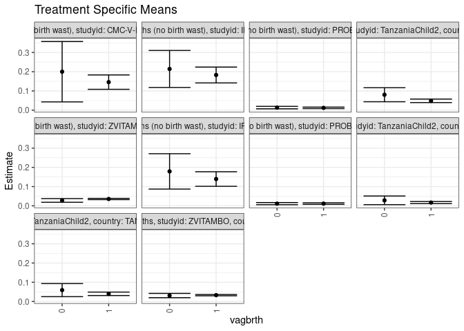

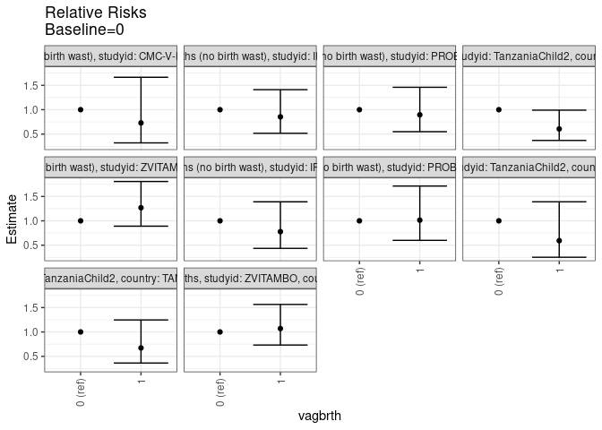

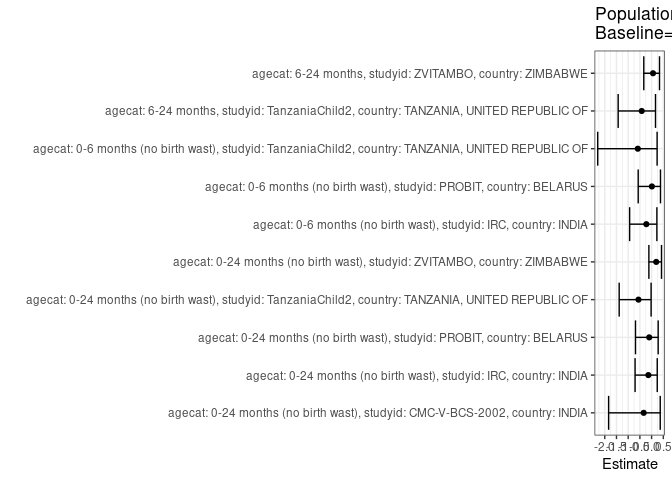

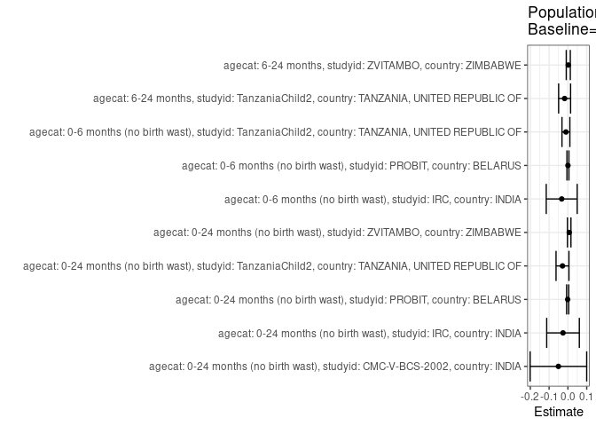

## Results Table

### Parameter: TSM

| agecat | studyid | country | intervention_level | baseline_level | estimate | ci_lower | ci_upper |
| --- | --- | --- | --- | --- | --- | --- | --- |
| 0-24 months (no birth wast) | CMC-V-BCS-2002 | INDIA | 0 | NA | 0.2000000 | 0.0429894 | 0.3570106 |
| 0-24 months (no birth wast) | CMC-V-BCS-2002 | INDIA | 1 | NA | 0.1457726 | 0.1083773 | 0.1831679 |
| 0-24 months (no birth wast) | IRC | INDIA | 0 | NA | 0.2142857 | 0.1180448 | 0.3105266 |
| 0-24 months (no birth wast) | IRC | INDIA | 1 | NA | 0.1828909 | 0.1416891 | 0.2240926 |
| 0-24 months (no birth wast) | PROBIT | BELARUS | 0 | NA | 0.0133197 | 0.0069674 | 0.0196720 |
| 0-24 months (no birth wast) | PROBIT | BELARUS | 1 | NA | 0.0119247 | 0.0079866 | 0.0158628 |
| 0-24 months (no birth wast) | TanzaniaChild2 | TANZANIA, UNITED REPUBLIC OF | 0 | NA | 0.0801887 | 0.0436226 | 0.1167547 |
| 0-24 months (no birth wast) | TanzaniaChild2 | TANZANIA, UNITED REPUBLIC OF | 1 | NA | 0.0485301 | 0.0394303 | 0.0576299 |
| 0-24 months (no birth wast) | ZVITAMBO | ZIMBABWE | 0 | NA | 0.0280210 | 0.0184490 | 0.0375930 |
| 0-24 months (no birth wast) | ZVITAMBO | ZIMBABWE | 1 | NA | 0.0355412 | 0.0322797 | 0.0388027 |
| 0-6 months (no birth wast) | IRC | INDIA | 0 | NA | 0.1791045 | 0.0871728 | 0.2710362 |
| 0-6 months (no birth wast) | IRC | INDIA | 1 | NA | 0.1393189 | 0.1015068 | 0.1771310 |
| 0-6 months (no birth wast) | PROBIT | BELARUS | 0 | NA | 0.0113636 | 0.0057775 | 0.0169498 |
| 0-6 months (no birth wast) | PROBIT | BELARUS | 1 | NA | 0.0115200 | 0.0075096 | 0.0155304 |
| 0-6 months (no birth wast) | TanzaniaChild2 | TANZANIA, UNITED REPUBLIC OF | 0 | NA | 0.0284360 | 0.0060039 | 0.0508681 |
| 0-6 months (no birth wast) | TanzaniaChild2 | TANZANIA, UNITED REPUBLIC OF | 1 | NA | 0.0168539 | 0.0113938 | 0.0223140 |
| 6-24 months | TanzaniaChild2 | TANZANIA, UNITED REPUBLIC OF | 0 | NA | 0.0591398 | 0.0252317 | 0.0930478 |
| 6-24 months | TanzaniaChild2 | TANZANIA, UNITED REPUBLIC OF | 1 | NA | 0.0397790 | 0.0307730 | 0.0487850 |
| 6-24 months | ZVITAMBO | ZIMBABWE | 0 | NA | 0.0307692 | 0.0195485 | 0.0419899 |
| 6-24 months | ZVITAMBO | ZIMBABWE | 1 | NA | 0.0329155 | 0.0293853 | 0.0364457 |

### Parameter: E(Y)

| agecat | studyid | country | intervention_level | baseline_level | estimate | ci_lower | ci_upper |
| --- | --- | --- | --- | --- | --- | --- | --- |
| 0-24 months (no birth wast) | CMC-V-BCS-2002 | INDIA | NA | NA | 0.1494565 | 0.1129794 | 0.1859337 |
| 0-24 months (no birth wast) | IRC | INDIA | NA | NA | 0.1882641 | 0.1503318 | 0.2261964 |
| 0-24 months (no birth wast) | PROBIT | BELARUS | NA | NA | 0.0120860 | 0.0083142 | 0.0158578 |
| 0-24 months (no birth wast) | TanzaniaChild2 | TANZANIA, UNITED REPUBLIC OF | NA | NA | 0.0513800 | 0.0424616 | 0.0602985 |
| 0-24 months (no birth wast) | ZVITAMBO | ZIMBABWE | NA | NA | 0.0349061 | 0.0318124 | 0.0379998 |
| 0-6 months (no birth wast) | IRC | INDIA | NA | NA | 0.1461538 | 0.1110489 | 0.1812588 |
| 0-6 months (no birth wast) | PROBIT | BELARUS | NA | NA | 0.0115018 | 0.0077384 | 0.0152653 |
| 0-6 months (no birth wast) | TanzaniaChild2 | TANZANIA, UNITED REPUBLIC OF | NA | NA | 0.0178952 | 0.0125307 | 0.0232597 |
| 6-24 months | TanzaniaChild2 | TANZANIA, UNITED REPUBLIC OF | NA | NA | 0.0415832 | 0.0328230 | 0.0503433 |
| 6-24 months | ZVITAMBO | ZIMBABWE | NA | NA | 0.0327334 | 0.0293653 | 0.0361014 |

### Parameter: RR

| agecat | studyid | country | intervention_level | baseline_level | estimate | ci_lower | ci_upper |
| --- | --- | --- | --- | --- | --- | --- | --- |
| 0-24 months (no birth wast) | CMC-V-BCS-2002 | INDIA | 0 | 0 | 1.0000000 | 1.0000000 | 1.0000000 |
| 0-24 months (no birth wast) | CMC-V-BCS-2002 | INDIA | 1 | 0 | 0.7288630 | 0.3191248 | 1.6646817 |
| 0-24 months (no birth wast) | IRC | INDIA | 0 | 0 | 1.0000000 | 1.0000000 | 1.0000000 |
| 0-24 months (no birth wast) | IRC | INDIA | 1 | 0 | 0.8534907 | 0.5163975 | 1.4106310 |
| 0-24 months (no birth wast) | PROBIT | BELARUS | 0 | 0 | 1.0000000 | 1.0000000 | 1.0000000 |
| 0-24 months (no birth wast) | PROBIT | BELARUS | 1 | 0 | 0.8952698 | 0.5491424 | 1.4595631 |
| 0-24 months (no birth wast) | TanzaniaChild2 | TANZANIA, UNITED REPUBLIC OF | 0 | 0 | 1.0000000 | 1.0000000 | 1.0000000 |
| 0-24 months (no birth wast) | TanzaniaChild2 | TANZANIA, UNITED REPUBLIC OF | 1 | 0 | 0.6051989 | 0.3696326 | 0.9908911 |
| 0-24 months (no birth wast) | ZVITAMBO | ZIMBABWE | 0 | 0 | 1.0000000 | 1.0000000 | 1.0000000 |
| 0-24 months (no birth wast) | ZVITAMBO | ZIMBABWE | 1 | 0 | 1.2683764 | 0.8904991 | 1.8066033 |
| 0-6 months (no birth wast) | IRC | INDIA | 0 | 0 | 1.0000000 | 1.0000000 | 1.0000000 |
| 0-6 months (no birth wast) | IRC | INDIA | 1 | 0 | 0.7778638 | 0.4352533 | 1.3901609 |
| 0-6 months (no birth wast) | PROBIT | BELARUS | 0 | 0 | 1.0000000 | 1.0000000 | 1.0000000 |
| 0-6 months (no birth wast) | PROBIT | BELARUS | 1 | 0 | 1.0137562 | 0.5997470 | 1.7135584 |
| 0-6 months (no birth wast) | TanzaniaChild2 | TANZANIA, UNITED REPUBLIC OF | 0 | 0 | 1.0000000 | 1.0000000 | 1.0000000 |
| 0-6 months (no birth wast) | TanzaniaChild2 | TANZANIA, UNITED REPUBLIC OF | 1 | 0 | 0.5926966 | 0.2526208 | 1.3905792 |
| 6-24 months | TanzaniaChild2 | TANZANIA, UNITED REPUBLIC OF | 0 | 0 | 1.0000000 | 1.0000000 | 1.0000000 |
| 6-24 months | TanzaniaChild2 | TANZANIA, UNITED REPUBLIC OF | 1 | 0 | 0.6726268 | 0.3631281 | 1.2459153 |
| 6-24 months | ZVITAMBO | ZIMBABWE | 0 | 0 | 1.0000000 | 1.0000000 | 1.0000000 |
| 6-24 months | ZVITAMBO | ZIMBABWE | 1 | 0 | 1.0697544 | 0.7314784 | 1.5644678 |

### Parameter: PAR

| agecat | studyid | country | intervention_level | baseline_level | estimate | ci_lower | ci_upper |
| --- | --- | --- | --- | --- | --- | --- | --- |
| 0-24 months (no birth wast) | CMC-V-BCS-2002 | INDIA | 0 | NA | -0.0505435 | -0.2009875 | 0.0999006 |
| 0-24 months (no birth wast) | IRC | INDIA | 0 | NA | -0.0260217 | -0.1128012 | 0.0607579 |
| 0-24 months (no birth wast) | PROBIT | BELARUS | 0 | NA | -0.0012336 | -0.0068499 | 0.0043826 |
| 0-24 months (no birth wast) | TanzaniaChild2 | TANZANIA, UNITED REPUBLIC OF | 0 | NA | -0.0288086 | -0.0630998 | 0.0054825 |
| 0-24 months (no birth wast) | ZVITAMBO | ZIMBABWE | 0 | NA | 0.0068851 | -0.0023733 | 0.0161434 |
| 0-6 months (no birth wast) | IRC | INDIA | 0 | NA | -0.0329506 | -0.1152912 | 0.0493899 |
| 0-6 months (no birth wast) | PROBIT | BELARUS | 0 | NA | 0.0001382 | -0.0051557 | 0.0054321 |
| 0-6 months (no birth wast) | TanzaniaChild2 | TANZANIA, UNITED REPUBLIC OF | 0 | NA | -0.0105408 | -0.0315527 | 0.0104710 |
| 6-24 months | TanzaniaChild2 | TANZANIA, UNITED REPUBLIC OF | 0 | NA | -0.0175566 | -0.0493719 | 0.0142587 |
| 6-24 months | ZVITAMBO | ZIMBABWE | 0 | NA | 0.0019641 | -0.0088005 | 0.0127288 |

### Parameter: PAF

| agecat | studyid | country | intervention_level | baseline_level | estimate | ci_lower | ci_upper |
| --- | --- | --- | --- | --- | --- | --- | --- |
| 0-24 months (no birth wast) | CMC-V-BCS-2002 | INDIA | 0 | NA | -0.3381818 | -1.8354235 | 0.3684433 |
| 0-24 months (no birth wast) | IRC | INDIA | 0 | NA | -0.1382189 | -0.7058900 | 0.2405476 |
| 0-24 months (no birth wast) | PROBIT | BELARUS | 0 | NA | -0.1020723 | -0.6879339 | 0.2804438 |
| 0-24 months (no birth wast) | TanzaniaChild2 | TANZANIA, UNITED REPUBLIC OF | 0 | NA | -0.5606970 | -1.3844507 | -0.0215247 |
| 0-24 months (no birth wast) | ZVITAMBO | ZIMBABWE | 0 | NA | 0.1972454 | -0.1163068 | 0.4227259 |
| 0-6 months (no birth wast) | IRC | INDIA | 0 | NA | -0.2254517 | -0.9382973 | 0.2252314 |
| 0-6 months (no birth wast) | PROBIT | BELARUS | 0 | NA | 0.0120147 | -0.5725456 | 0.3792771 |
| 0-6 months (no birth wast) | TanzaniaChild2 | TANZANIA, UNITED REPUBLIC OF | 0 | NA | -0.5890318 | -2.3006805 | 0.2349995 |
| 6-24 months | TanzaniaChild2 | TANZANIA, UNITED REPUBLIC OF | 0 | NA | -0.4222049 | -1.4277873 | 0.1668681 |
| 6-24 months | ZVITAMBO | ZIMBABWE | 0 | NA | 0.0600044 | -0.3336426 | 0.3374599 |